# PROJECT-412-DENİZCAN-TAŞDELEN

assign data_robust

```r
data_robust <- train.data
```

```r
glimpse(data_robust)
```

```
## Rows: 165
## Columns: 29
## $ price                <dbl> 13495, 16500, 13950, 17450, 15250, 17710, 25552, ~
## $ CarName.bmw          <dbl> 0, 0, 0, 0, 0, 0, 0, 0, 1, 1, 1, 1, 1, 1, 0, 0, 0~
## $ CarName.buick        <dbl> 0, 0, 0, 0, 0, 0, 0, 0, 0, 0, 0, 0, 0, 0, 0, 0, 0~
## $ CarName.porsche      <dbl> 0, 0, 0, 0, 0, 0, 0, 0, 0, 0, 0, 0, 0, 0, 0, 0, 0~
## $ CarName.toyota       <dbl> 0, 0, 0, 0, 0, 0, 0, 0, 0, 0, 0, 0, 0, 0, 0, 0, 0~
## $ aspiration.std       <dbl> 1, 1, 1, 1, 1, 1, 1, 0, 1, 1, 1, 1, 1, 1, 1, 1, 1~
## $ aspiration.turbo     <dbl> 0, 0, 0, 0, 0, 0, 0, 1, 0, 0, 0, 0, 0, 0, 0, 0, 0~
## $ drivewheel.fwd       <dbl> 0, 0, 1, 0, 1, 1, 1, 1, 0, 0, 0, 0, 0, 0, 1, 1, 1~
## $ drivewheel.rwd       <dbl> 1, 1, 0, 1, 0, 0, 0, 0, 1, 1, 1, 1, 1, 1, 0, 0, 0~
## $ wheelbase            <dbl> 89.5, 94.5, 99.8, 99.4, 99.8, 105.8, 105.8, 105.8~
## $ carlength            <dbl> 168.8, 171.2, 176.6, 176.6, 177.3, 192.7, 192.7, ~
## $ carwidth             <dbl> 64.1, 65.5, 66.2, 66.4, 66.3, 71.4, 71.4, 71.4, 6~
## $ carheight            <dbl> 48.8, 52.4, 54.3, 54.3, 53.1, 55.7, 55.7, 55.9, 5~
```

[output cut: 16 more lines]

one hot encoding.

```r
dummy_robust <- dummyVars(" ~ .", data=data_robust)

#perform one-hot encoding on data frame
final_df_robust <- data.frame(predict(dummy_robust, newdata=data_robust))
```

Alliased variable aspiration.std is discarded.

```r
final_df_robust <- final_df_robust %>% select(-aspiration.std)
```

apply linear model.

```r
model_lm <- lm(price ~ ., data=final_df_robust)
```

```r
summary(model_lm)
```

```
##
## Call:
## lm(formula = price ~ ., data = final_df_robust)
##
## Residuals:
##     Min      1Q  Median      3Q     Max
## -5526.9 -1237.1   -49.0   893.4 10790.5
##
## Coefficients:
##                        Estimate Std. Error t value Pr(>|t|)
## (Intercept)          -3.511e+04  1.534e+04  -2.288 0.023646 *
## CarName.bmw           7.181e+03  1.395e+03   5.147 9.01e-07 ***
## CarName.buick         7.496e+03  1.744e+03   4.299 3.23e-05 ***
## CarName.porsche       7.919e+03  1.743e+03   4.544 1.20e-05 ***
## CarName.toyota       -1.240e+03  6.233e+02  -1.990 0.048556 *
## aspiration.turbo      1.486e+03  9.446e+02   1.573 0.117955
## drivewheel.fwd       -1.166e+03  1.394e+03  -0.837 0.404101
## drivewheel.rwd        2.174e+02  1.500e+03   0.145 0.884922
## wheelbase             2.558e+01  9.757e+01   0.262 0.793623
## carlength             1.858e+01  5.345e+01   0.348 0.728733
## carwidth              4.797e+02  2.614e+02   1.835 0.068667 .
## carheight             5.705e+01  1.344e+02   0.424 0.671967
## curbweight            1.619e+00  1.628e+00   0.994 0.321774
## enginetype.l         -8.794e+02  1.611e+03  -0.546 0.586012
## enginetype.ohc        1.346e+03  9.501e+02   1.416 0.158962
## cylindernumber.eight -1.231e+03  2.038e+03  -0.604 0.546790
## cylindernumber.four  -3.761e+03  9.533e+02  -3.945 0.000127 ***
## cylindernumber.six   -2.595e+03  1.208e+03  -2.148 0.033500 *
## enginesize            6.850e+01  1.381e+01   4.961 2.04e-06 ***
## fuelsystem.2bbl       4.502e+02  8.623e+02   0.522 0.602502
## fuelsystem.mpfi       5.706e+02  8.608e+02   0.663 0.508556
## boreratio            -1.437e+03  1.454e+03  -0.988 0.324740
## stroke               -2.717e+03  8.979e+02  -3.026 0.002962 **
## compressionratio      1.228e+02  1.044e+02   1.177 0.241354
## horsepower            2.502e+01  1.880e+01   1.331 0.185365
## peakrpm               1.127e+00  7.239e-01   1.557 0.121886
## citympg              -1.131e+02  1.852e+02  -0.611 0.542379
## highwaympg            1.147e+02  1.522e+02   0.754 0.452322
## ---
## Signif. codes:  0 '***' 0.001 '**' 0.01 '*' 0.05 '.' 0.1 ' ' 1
##
## Residual standard error: 2548 on 137 degrees of freedom
## Multiple R-squared:  0.9234, Adjusted R-squared:  0.9083
## F-statistic: 61.17 on 27 and 137 DF,  p-value: < 2.2e-16
```

apply step forward elimination

```r
ols_step_forward_p(model_lm, details = F)
```

```
##
##                                     Selection Summary
## -----------------------------------------------------------------------------------------
##         Variable                             Adj.
## Step          Entered          R-Square    R-Square      C(p)         AIC         RMSE
## -----------------------------------------------------------------------------------------
##    1    enginesize               0.7421      0.7405    300.3327    3232.0838    4286.2635
##    2    carwidth                 0.7921      0.7895    212.8400    3198.5006    3859.9895
##    3    CarName.porsche          0.8247      0.8214    156.5730    3172.3794    3555.6740
##    4    CarName.bmw              0.8603      0.8568     94.8553    3136.8996    3183.8299
##    5    CarName.buick            0.8791      0.8753     63.2544    3115.0693    2971.3205
##    6    cylindernumber.four      0.8941      0.8901     38.3443    3095.1426    2789.0936
##    7    stroke                   0.8990      0.8945     31.5847    3089.3271    2732.4754
##    8    aspiration.turbo         0.9044      0.8994     24.0673    3082.3935    2668.0058
##    9    peakrpm                  0.9080      0.9027     19.5171    3077.9515    2624.8545
##   10    enginetype.ohc           0.9105      0.9047     16.9875    3075.3449    2596.8581
##   11    drivewheel.fwd           0.9146      0.9084     11.7769    3069.7356    2545.9429
##   12    CarName.toyota           0.9172      0.9107      9.0881    3066.5923    2514.8021
##   13    curbweight               0.9182      0.9111      9.3238    3066.6148    2508.0410
##   14    cylindernumber.six       0.9196      0.9121      8.7137    3065.6450    2493.8428
##   15    compressionratio         0.9203      0.9122      9.5927    3066.3528    2492.4191
##   16    horsepower               0.9216      0.9131      9.2974    3065.6752    2480.6156
## -----------------------------------------------------------------------------------------
```

```r
selected_forward <- c("price", "enginesize", "carwidth", "CarName.porsche", "CarName.bmw",
                      "CarName.buick",
                      "cylindernumber.four", "stroke", "aspiration.turbo", "peakrpm", "enginetype.ohc",
                      "drivewheel.fwd", "CarName.toyota", "curbweight", "cylindernumber.six",
                      "compressionratio",
                      "horsepower")

lm_data <- final_df_robust[, selected_forward]

model_lm_3 <- lm(price ~ ., data=lm_data)

summary(model_lm_3)
```

```
##
## Call:
## lm(formula = price ~ ., data = lm_data)
##
## Residuals:
##     Min      1Q  Median      3Q     Max
## -6432.4 -1277.4     7.4   948.4 10518.0
##
## Coefficients:
##                       Estimate Std. Error t value Pr(>|t|)
## (Intercept)         -35574.759  11818.230  -3.010  0.00307 **
## enginesize              65.356     12.798   5.107 9.94e-07 ***
## carwidth               578.861    197.752   2.927  0.00396 **
## CarName.porsche       7540.704   1395.349   5.404 2.55e-07 ***
## CarName.bmw           6937.564   1262.116   5.497 1.65e-07 ***
## CarName.buick         7093.902   1316.390   5.389 2.73e-07 ***
## cylindernumber.four  -3815.432    796.791  -4.789 4.04e-06 ***
## stroke               -3140.162    762.693  -4.117 6.35e-05 ***
## aspiration.turbo      1122.430    788.656   1.423  0.15678
## peakrpm                  1.154      0.591   1.952  0.05281 .
## enginetype.ohc        1984.295    627.370   3.163  0.00190 **
## drivewheel.fwd       -1077.781    614.077  -1.755  0.08131 .
## CarName.toyota       -1146.544    582.538  -1.968  0.05091 .
## curbweight               1.856      1.185   1.566  0.11945
## cylindernumber.six   -1684.983   1007.164  -1.673  0.09644 .
## compressionratio       108.002     66.635   1.621  0.10719
## horsepower              22.756     14.624   1.556  0.12183
## ---
## Signif. codes:  0 '***' 0.001 '**' 0.01 '*' 0.05 '.' 0.1 ' ' 1
##
## Residual standard error: 2481 on 148 degrees of freedom
## Multiple R-squared:  0.9216, Adjusted R-squared:  0.9131
## F-statistic: 108.7 on 16 and 148 DF,  p-value: < 2.2e-16
```

When we discard curbweight variable, change in the coefficients is huge which is an indication of multicollinearity in the model.

```r
model_try_1 <- lm(price ~. -curbweight, data=lm_data)
summary(model_try_1)
```

```
##
## Call:
## lm(formula = price ~ . - curbweight, data = lm_data)
##
## Residuals:
##     Min      1Q  Median      3Q     Max
## -6613.2 -1261.8  -101.5   920.0 10621.3
##
## Coefficients:
##                       Estimate Std. Error t value Pr(>|t|)
## (Intercept)         -4.372e+04  1.066e+04  -4.100 6.76e-05 ***
## enginesize           7.199e+01  1.214e+01   5.932 2.01e-08 ***
## carwidth             7.745e+02  1.540e+02   5.028 1.40e-06 ***
## CarName.porsche      7.024e+03  1.362e+03   5.156 7.91e-07 ***
## CarName.bmw          6.755e+03  1.263e+03   5.349 3.26e-07 ***
## CarName.buick        7.128e+03  1.323e+03   5.389 2.71e-07 ***
## cylindernumber.four -3.627e+03  7.915e+02  -4.583 9.64e-06 ***
## stroke              -3.153e+03  7.664e+02  -4.114 6.40e-05 ***
## aspiration.turbo     1.245e+03  7.886e+02   1.578  0.11661
## peakrpm              9.815e-01  5.835e-01   1.682  0.09463 .
## enginetype.ohc       1.905e+03  6.284e+02   3.032  0.00287 **
## drivewheel.fwd      -1.557e+03  5.351e+02  -2.909  0.00418 **
## CarName.toyota      -1.280e+03  5.791e+02  -2.210  0.02860 *
## cylindernumber.six  -1.337e+03  9.871e+02  -1.355  0.17762
## compressionratio     1.105e+02  6.694e+01   1.650  0.10100
## horsepower           2.486e+01  1.463e+01   1.699  0.09148 .
## ---
## Signif. codes:  0 '***' 0.001 '**' 0.01 '*' 0.05 '.' 0.1 ' ' 1
##
## Residual standard error: 2493 on 149 degrees of freedom
## Multiple R-squared:  0.9203, Adjusted R-squared:  0.9122
## F-statistic: 114.6 on 15 and 149 DF,  p-value: < 2.2e-16
```

vif value of curbweight variable is greater than 10. It causes multicollinearity in the model. So, it will be discarded.

```r
car::vif(model_lm_3)
```

```
##          enginesize            carwidth     CarName.porsche         CarName.bmw
##            9.177103            5.444578            1.829409            1.496732
##       CarName.buick cylindernumber.four              stroke    aspiration.turbo
##            1.887650            3.072704            1.469377            2.144075
##             peakrpm      enginetype.ohc      drivewheel.fwd      CarName.toyota
##            2.177824            2.063873            2.494329            1.282106
##          curbweight  cylindernumber.six    compressionratio          horsepower
##           11.011113            2.897316            1.935032            9.639290
```

Discard curbweight variable.

```r
lm_data <- lm_data %>% select(-curbweight)
```

Conduct lm again. There are some insignificant variables.

```r
model_lm_4 <- lm(price ~ ., data=lm_data)

summary(model_lm_4)
```

```
##
## Call:
## lm(formula = price ~ ., data = lm_data)
##
## Residuals:
##     Min      1Q  Median      3Q     Max
## -6613.2 -1261.8  -101.5   920.0 10621.3
##
## Coefficients:
##                       Estimate Std. Error t value Pr(>|t|)
## (Intercept)         -4.372e+04  1.066e+04  -4.100 6.76e-05 ***
## enginesize           7.199e+01  1.214e+01   5.932 2.01e-08 ***
## carwidth             7.745e+02  1.540e+02   5.028 1.40e-06 ***
## CarName.porsche      7.024e+03  1.362e+03   5.156 7.91e-07 ***
## CarName.bmw          6.755e+03  1.263e+03   5.349 3.26e-07 ***
## CarName.buick        7.128e+03  1.323e+03   5.389 2.71e-07 ***
## cylindernumber.four -3.627e+03  7.915e+02  -4.583 9.64e-06 ***
## stroke              -3.153e+03  7.664e+02  -4.114 6.40e-05 ***
## aspiration.turbo     1.245e+03  7.886e+02   1.578  0.11661
## peakrpm              9.815e-01  5.835e-01   1.682  0.09463 .
## enginetype.ohc       1.905e+03  6.284e+02   3.032  0.00287 **
## drivewheel.fwd      -1.557e+03  5.351e+02  -2.909  0.00418 **
## CarName.toyota      -1.280e+03  5.791e+02  -2.210  0.02860 *
## cylindernumber.six  -1.337e+03  9.871e+02  -1.355  0.17762
## compressionratio     1.105e+02  6.694e+01   1.650  0.10100
## horsepower           2.486e+01  1.463e+01   1.699  0.09148 .
## ---
## Signif. codes:  0 '***' 0.001 '**' 0.01 '*' 0.05 '.' 0.1 ' ' 1
##
## Residual standard error: 2493 on 149 degrees of freedom
## Multiple R-squared:  0.9203, Adjusted R-squared:  0.9122
## F-statistic: 114.6 on 15 and 149 DF,  p-value: < 2.2e-16
```

No multicollinearity problem anymore.

```r
car::vif(model_lm_4)
```

```
##          enginesize            carwidth     CarName.porsche         CarName.bmw
##            8.171991            3.271604            1.727270            1.483973
##       CarName.buick cylindernumber.four              stroke    aspiration.turbo
##            1.887136            3.002753            1.469204            2.123073
##             peakrpm      enginetype.ohc      drivewheel.fwd      CarName.toyota
##            2.102487            2.050442            1.875768            1.254670
##  cylindernumber.six    compressionratio          horsepower
##            2.756393            1.933951            9.558242
```

discarding insignificant variables.

```r
lm_data <- lm_data %>% select(-cylindernumber.six)
lm_data <- lm_data %>% select(-aspiration.turbo)
lm_data <- lm_data %>% select(-peakrpm)
```

Conduct lm again.

```r
model_lm_5 <- lm(price ~ ., data=lm_data)

summary(model_lm_5)
```

```
##
## Call:
## lm(formula = price ~ ., data = lm_data)
##
## Residuals:
##     Min      1Q  Median      3Q     Max
## -7385.0 -1358.3   -34.6   942.1 10118.0
##
## Coefficients:
##                      Estimate Std. Error t value Pr(>|t|)
## (Intercept)         -44171.14    9249.52  -4.776 4.18e-06 ***
## enginesize              53.99       9.75   5.538 1.31e-07 ***
## carwidth               853.15     145.50   5.864 2.72e-08 ***
## CarName.porsche       6801.32    1309.89   5.192 6.57e-07 ***
## CarName.bmw           5960.76    1213.83   4.911 2.32e-06 ***
## CarName.buick         7837.19    1274.94   6.147 6.64e-09 ***
## cylindernumber.four  -2894.43     637.22  -4.542 1.13e-05 ***
## stroke               -3068.86     753.92  -4.071 7.52e-05 ***
## enginetype.ohc        2059.95     617.78   3.334 0.001074 **
## drivewheel.fwd       -1624.21     539.82  -3.009 0.003071 **
## CarName.toyota       -1658.27     563.60  -2.942 0.003769 **
## compressionratio       119.72      57.21   2.092 0.038059 *
## horsepower              41.17      12.09   3.405 0.000847 ***
## ---
## Signif. codes:  0 '***' 0.001 '**' 0.01 '*' 0.05 '.' 0.1 ' ' 1
##
## Residual standard error: 2520 on 152 degrees of freedom
## Multiple R-squared:  0.9169, Adjusted R-squared:  0.9103
## F-statistic: 139.7 on 12 and 152 DF,  p-value: < 2.2e-16
```

not constant variance.

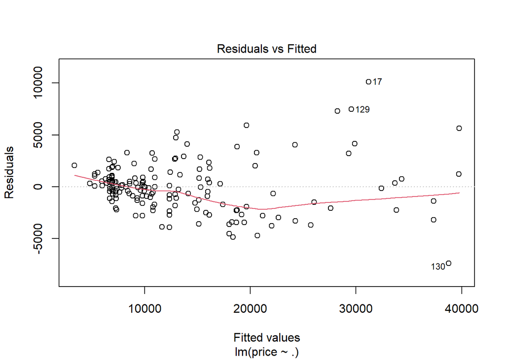

```r
plot(model_lm_5,1)
```

there is normality problem.

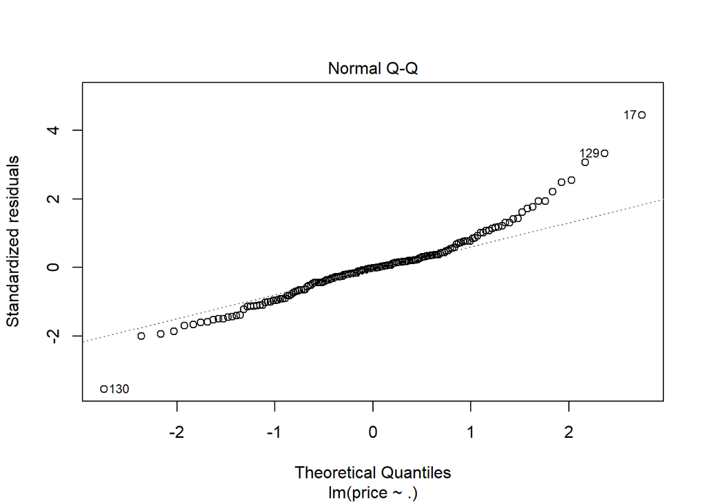

```r
plot(model_lm_5,2)
```

not normal dependent.

```r
shapiro.test(lm_data$price)
```

```
##
##  Shapiro-Wilk normality test
##
## data:  lm_data$price
## W = 0.79979, p-value = 9.24e-14
```

Since the distribution is right skewed, transformation on the response was applied.

After transformation, p-value > 0.05 meaning that dependent distribute normally.

```r
orderNorm(lm_data$price)
```

```
## orderNorm Transformation with 165 nonmissing obs and ties
##  - 146 unique values
##  - Original quantiles:
##    0%   25%   50%   75%  100%
##  5118  7775 10245 16430 45400
```

```r
new_response <- orderNorm(lm_data$price)$x.t

shapiro.test(new_response)
```

```
##
##  Shapiro-Wilk normality test
##
## data:  new_response
## W = 0.99967, p-value = 1
```

Change “price” with the transformed “new_response”.

```r
price <- lm_data$price
lm_data <- lm_data %>% select(-price)
```

```r
lm_data <- cbind(new_response, lm_data)
```

Apply lm again.

```r
model_lm_6 <- lm(new_response ~ ., data=lm_data)

summary(model_lm_6)
```

```
##
## Call:
## lm(formula = new_response ~ ., data = lm_data)
##
## Residuals:
##      Min       1Q   Median       3Q      Max
## -1.74052 -0.20950  0.06108  0.24251  0.88043
##
## Coefficients:
##                       Estimate Std. Error t value Pr(>|t|)
## (Intercept)         -13.465502   1.557496  -8.646 6.99e-15 ***
## enginesize            0.001885   0.001642   1.148 0.252748
## carwidth              0.189297   0.024500   7.727 1.39e-12 ***
## CarName.porsche       0.293668   0.220569   1.331 0.185046
## CarName.bmw           0.532552   0.204393   2.606 0.010085 *
## CarName.buick        -0.003439   0.214683  -0.016 0.987240
## cylindernumber.four  -0.066628   0.107299  -0.621 0.535558
## stroke                0.009957   0.126950   0.078 0.937588
## enginetype.ohc        0.175540   0.104026   1.687 0.093566 .
## drivewheel.fwd       -0.435836   0.090899  -4.795 3.85e-06 ***
## CarName.toyota       -0.113641   0.094903  -1.197 0.232999
## compressionratio      0.008503   0.009634   0.883 0.378831
## horsepower            0.007363   0.002036   3.616 0.000407 ***
## ---
## Signif. codes:  0 '***' 0.001 '**' 0.01 '*' 0.05 '.' 0.1 ' ' 1
##
## Residual standard error: 0.4243 on 152 degrees of freedom
## Multiple R-squared:  0.8328, Adjusted R-squared:  0.8196
## F-statistic: 63.11 on 12 and 152 DF,  p-value: < 2.2e-16
```

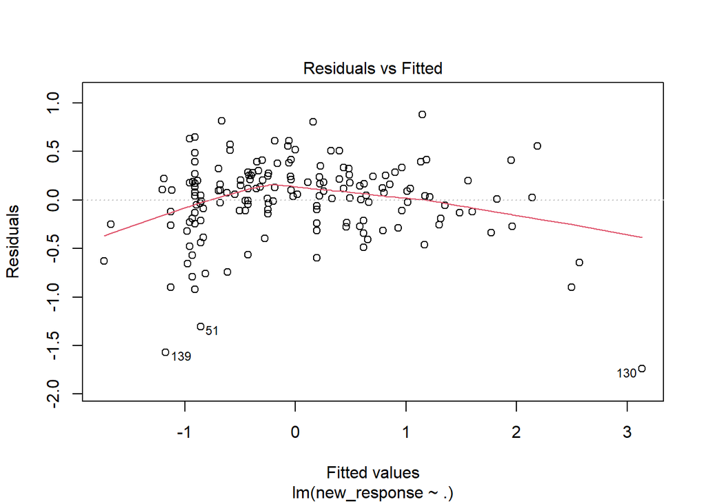

```r
plot(model_lm_6, 1)
```

There are some oulier points leading to non normailty.

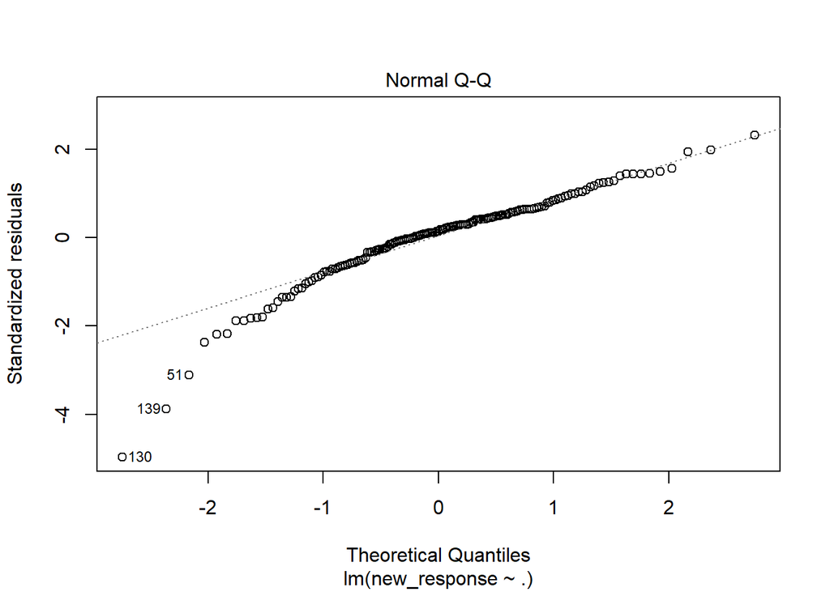

```r
plot(model_lm_6, 2)
```

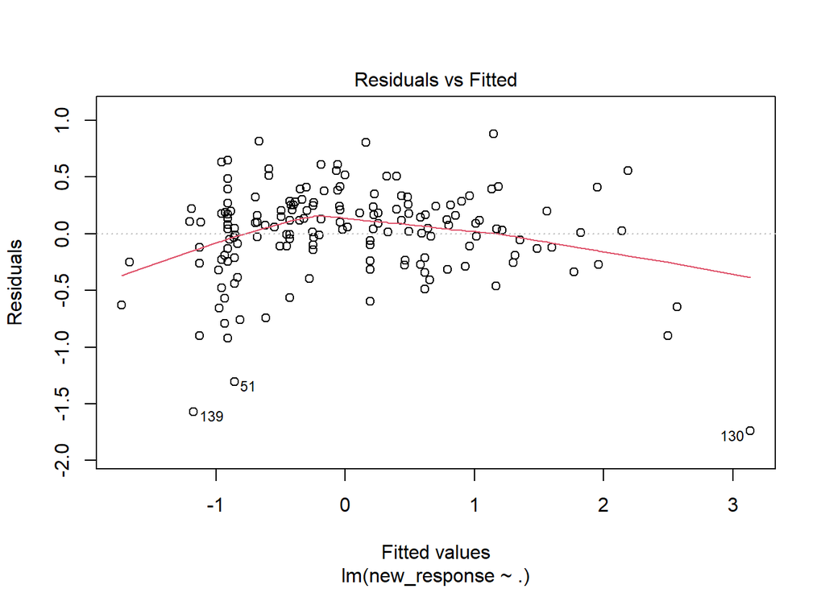

```r
plot(model_lm_6, 1)
```

Apply robust regression with huber.

```r
robust <- rlm(new_response ~ ., data=lm_data, psi = psi.huber)
summary(robust)
```

```
##
## Call: rlm(formula = new_response ~ ., data = lm_data, psi = psi.huber)
## Residuals:
##      Min       1Q   Median       3Q      Max
## -2.26115 -0.22119  0.03651  0.20675  0.95062
##
## Coefficients:
##                     Value    Std. Error t value
## (Intercept)         -13.9044   1.2544   -11.0843
## enginesize            0.0001   0.0013     0.1078
## carwidth              0.2016   0.0197    10.2162
## CarName.porsche       0.4594   0.1776     2.5860
## CarName.bmw           0.6384   0.1646     3.8777
## CarName.buick         0.0429   0.1729     0.2484
## cylindernumber.four  -0.0600   0.0864    -0.6945
## stroke               -0.1163   0.1022    -1.1374
## enginetype.ohc        0.1499   0.0838     1.7888
## drivewheel.fwd       -0.3332   0.0732    -4.5507
## CarName.toyota       -0.0871   0.0764    -1.1400
## compressionratio      0.0101   0.0078     1.2978
## horsepower            0.0096   0.0016     5.8353
##
## Residual standard error: 0.3216 on 152 degrees of freedom
```